# Expansión de la CASEN sobre el CENSO (Región 12)

De ingresos sobre una categoría de respuesta **RURAL

VE-CC-AJ

DataIntelligence

Martes 06-07-2021

Abstract

Expandiremos los ingresos promedios comunales obtenidos de la CASEN sobre la pregunta (P15): “Nivel del curso más alto aprobado” en la categoría de respuesta “Profesional” (12), que más alto correlaciona con los ingresos expandidos (obtenidos de la multiplicación del ingreso promedio y los habitantes), ambos a nivel comunal.

Haremos el análisis sobre la región 12.

Ensayaremos diferentes modelos dentro del análisis de regresión cuya variable independiente será: “frecuencia de población que posee la variable Censal respecto a la zona” y la dependiente: “ingreso expandido de la Casen por zona”

Lo anterior para ir combinando a nivel nacional los mejores modelos para construir una tabla de valores predichos.

## 1 Variable CENSO

Necesitamos calcular las frecuencias a nivel censal de las respuestas correspondientes a la categoría: “Profesional (4 o más años)” del campo **P15** a nivel **rural** del Censo de personas. Recordemos que ésta fué la más alta correlación en relación a los ingresos expandidos [(ver punto 3.4 aquí)](https://rpubs.com/dataintelligence/corr_censo_casen_2017).

### 1.1 Lectura y filtrado de la tabla censal de personas

Leemos la tabla Censo 2017 de personas que ya tiene integrada la clave zonal:

```r
tabla_con_clave <- readRDS("../censo_personas_con_clave_17")
r3_100 <- tabla_con_clave[c(1:100),]
kbl(r3_100) %>%
  kable_styling(bootstrap_options = c("striped", "hover")) %>%
  kable_paper() %>%
  scroll_box(width = "100%", height = "300px")
```

| REGION | PROVINCIA | COMUNA | DC | AREA | ZC_LOC | ID_ZONA_LOC | NVIV | NHOGAR | PERSONAN | P07 | P08 | P09 | P10 | P10COMUNA | P10PAIS | P11 | P11COMUNA | P11PAIS | P12 | P12COMUNA | P12PAIS | P12A_LLEGADA | P12A_TRAMO | P13 | P14 | P15 | P15A | P16 | P16A | … |
| --- | --- | --- | --- | --- | --- | --- | --- | --- | --- | --- | --- | --- | --- | --- | --- | --- | --- | --- | --- | --- | --- | --- | --- | --- | --- | --- | --- | --- | --- | --- |
| 15 | 152 | 15202 | 1 | 2 | 6 | 13225 | 1 | 1 | 1 | 1 | 1 | 73 | 1 | 98 | 998 | 3 | 15101 | 998 | 1 | 98 | 998 | 9998 | 98 | 2 | 4 | 6 | 2 | 1 | 2 | … |
| 15 | 152 | 15202 | 1 | 2 | 6 | 13225 | 3 | 1 | 1 | 1 | 1 | 78 | 1 | 98 | 998 | 2 | 98 | 998 | 1 | 98 | 998 | 9998 | 98 | 3 | 98 | 98 | 98 | 1 | 2 | … |
| 15 | 152 | 15202 | 1 | 2 | 6 | 13225 | 3 | 1 | 2 | 2 | 2 | 78 | 1 | 98 | 998 | 2 | 98 | 998 | 1 | 98 | 998 | 9998 | 98 | 3 | 98 | 98 | 98 | 1 | 2 | … |
| 15 | 152 | 15202 | 1 | 2 | 6 | 13225 | 3 | 1 | 3 | 5 | 2 | 52 | 1 | 98 | 998 | 2 | 98 | 998 | 1 | 98 | 998 | 9998 | 98 | 1 | 2 | 5 | 2 | 1 | 2 | … |
| 15 | 152 | 15202 | 1 | 2 | 6 | 13225 | 3 | 1 | 4 | 11 | 1 | 44 | 1 | 98 | 998 | 2 | 98 | 998 | 1 | 98 | 998 | 9998 | 98 | 1 | 3 | 5 | 2 | 1 | 2 | … |
| 15 | 152 | 15202 | 1 | 2 | 6 | 13225 | 9 | 1 | 1 | 1 | 1 | 39 | 1 | 98 | 998 | 2 | 98 | 998 | 1 | 98 | 998 | 9998 | 98 | 2 | 8 | 5 | 1 | 1 | 2 | … |
| 15 | 152 | 15202 | 1 | 2 | 6 | 13225 | 9 | 1 | 2 | 2 | 2 | 35 | 1 | 98 | 998 | 2 | 98 | 998 | 1 | 98 | 998 | 9998 | 98 | 2 | 6 | 5 | 2 | 1 | 2 | … |
| 15 | 152 | 15202 | 1 | 2 | 6 | 13225 | 9 | 1 | 3 | 5 | 1 | 13 | 1 | 98 | 998 | 2 | 98 | 998 | 1 | 98 | 998 | 9998 | 98 | 1 | 7 | 5 | 2 | 1 | 2 | … |
| 15 | 152 | 15202 | 1 | 2 | 6 | 13225 | 9 | 1 | 4 | 5 | 1 | 12 | 1 | 98 | 998 | 2 | 98 | 998 | 1 | 98 | 998 | 9998 | 98 | 1 | 6 | 5 | 2 | 1 | 2 | … |
| 15 | 152 | 15202 | 1 | 2 | 6 | 13225 | 10 | 1 | 1 | 1 | 2 | 65 | 1 | 98 | 998 | 2 | 98 | 998 | 1 | 98 | 998 | 9998 | 98 | 2 | 4 | 5 | 2 | 1 | 2 | … |
| 15 | 152 | 15202 | 1 | 2 | 6 | 13225 | 13 | 1 | 1 | 1 | 1 | 50 | 1 | 98 | 998 | 2 | 98 | 998 | 1 | 98 | 998 | 9998 | 98 | 2 | 5 | 5 | 2 | 1 | 2 | … |
| 15 | 152 | 15202 | 1 | 2 | 6 | 13225 | 13 | 1 | 2 | 4 | 2 | 43 | 1 | 98 | 998 | 2 | 98 | 998 | 1 | 98 | 998 | 9998 | 98 | 2 | 6 | 5 | 2 | 1 | 2 | … |
| 15 | 152 | 15202 | 1 | 2 | 6 | 13225 | 13 | 1 | 3 | 5 | 1 | 15 | 3 | 15201 | 998 | 2 | 98 | 998 | 1 | 98 | 998 | 9998 | 98 | 1 | 1 | 7 | 2 | 1 | 2 | … |
| 15 | 152 | 15202 | 1 | 2 | 6 | 13225 | 16 | 1 | 1 | 1 | 1 | 75 | 1 | 98 | 998 | 2 | 98 | 998 | 1 | 98 | 998 | 9998 | 98 | 3 | 98 | 98 | 98 | 1 | 2 | … |
| 15 | 152 | 15202 | 1 | 2 | 6 | 13225 | 16 | 1 | 2 | 16 | 2 | 58 | 4 | 98 | 68 | 6 | 98 | 998 | 5 | 98 | 998 | 9999 | 1 | 3 | 98 | 98 | 98 | 1 | 2 | … |
| 15 | 152 | 15202 | 1 | 2 | 6 | 13225 | 16 | 1 | 3 | 2 | 2 | 70 | 1 | 98 | 998 | 2 | 98 | 998 | 1 | 98 | 998 | 9998 | 98 | 3 | 98 | 98 | 98 | 1 | 2 | … |
| 15 | 152 | 15202 | 1 | 2 | 6 | 13225 | 17 | 1 | 1 | 1 | 2 | 43 | 2 | 98 | 998 | 2 | 98 | 998 | 1 | 98 | 998 | 9998 | 98 | 2 | 8 | 5 | 1 | 1 | 2 | … |
| 15 | 152 | 15202 | 1 | 2 | 6 | 13225 | 17 | 1 | 2 | 4 | 1 | 55 | 2 | 98 | 998 | 2 | 98 | 998 | 1 | 98 | 998 | 9998 | 98 | 2 | 6 | 5 | 2 | 1 | 2 | … |
| 15 | 152 | 15202 | 1 | 2 | 6 | 13225 | 17 | 1 | 3 | 5 | 2 | 13 | 2 | 98 | 998 | 2 | 98 | 998 | 2 | 15101 | 998 | 9998 | 98 | 1 | 7 | 5 | 2 | 1 | 2 | … |
| 15 | 152 | 15202 | 1 | 2 | 6 | 13225 | 17 | 1 | 4 | 5 | 1 | 8 | 2 | 98 | 998 | 2 | 98 | 998 | 2 | 15101 | 998 | 9998 | 98 | 1 | 2 | 5 | 2 | 1 | 2 | … |
| 15 | 152 | 15202 | 1 | 2 | 6 | 13225 | 17 | 1 | 5 | 15 | 2 | 29 | 2 | 98 | 998 | 4 | 98 | 998 | 3 | 98 | 998 | 2015 | 1 | 2 | 6 | 5 | 2 | 1 | 2 | … |
| 15 | 152 | 15202 | 1 | 2 | 6 | 13225 | 17 | 1 | 6 | 15 | 1 | 4 | 2 | 98 | 998 | 1 | 98 | 998 | 5 | 98 | 998 | 2015 | 1 | 1 | 0 | 1 | 2 | 1 | 2 | … |
| 15 | 152 | 15202 | 1 | 2 | 6 | 13225 | 17 | 1 | 7 | 15 | 2 | 2 | 2 | 98 | 998 | 1 | 98 | 998 | 3 | 98 | 998 | 2015 | 1 | 1 | 0 | 1 | 2 | 1 | 2 | … |
| 15 | 152 | 15202 | 1 | 2 | 6 | 13225 | 17 | 1 | 8 | 15 | 1 | 16 | 2 | 98 | 998 | 6 | 98 | 998 | 1 | 98 | 998 | 9998 | 98 | 2 | 4 | 5 | 2 | 1 | 2 | … |
| 15 | 152 | 15202 | 1 | 2 | 6 | 13225 | 18 | 1 | 1 | 1 | 2 | 74 | 1 | 98 | 998 | 2 | 98 | 998 | 1 | 98 | 998 | 9998 | 98 | 2 | 2 | 5 | 2 | 1 | 2 | … |
| 15 | 152 | 15202 | 1 | 2 | 6 | 13225 | 19 | 1 | 1 | 1 | 1 | 68 | 1 | 98 | 998 | 2 | 98 | 998 | 1 | 98 | 998 | 9998 | 98 | 3 | 98 | 98 | 98 | 1 | 2 | … |
| 15 | 152 | 15202 | 1 | 2 | 6 | 13225 | 20 | 1 | 1 | 1 | 1 | 74 | 1 | 98 | 998 | 3 | 15101 | 998 | 1 | 98 | 998 | 9998 | 98 | 2 | 2 | 5 | 2 | 1 | 2 | … |
| 15 | 152 | 15202 | 1 | 2 | 6 | 13225 | 20 | 1 | 2 | 2 | 2 | 65 | 1 | 98 | 998 | 3 | 997 | 998 | 3 | 98 | 998 | 9999 | 2 | 2 | 2 | 5 | 2 | 1 | 2 | … |
| 15 | 152 | 15202 | 1 | 2 | 6 | 13225 | 25 | 1 | 1 | 1 | 2 | 76 | 1 | 98 | 998 | 2 | 98 | 998 | 1 | 98 | 998 | 9998 | 98 | 3 | 98 | 98 | 98 | 1 | 2 | … |
| 15 | 152 | 15202 | 1 | 2 | 6 | 13225 | 25 | 1 | 2 | 5 | 2 | 36 | 1 | 98 | 998 | 2 | 98 | 998 | 1 | 98 | 998 | 9998 | 98 | 2 | 4 | 8 | 1 | 1 | 2 | … |

[output cut: 70 more lines]

Despleguemos los códigos de regiones de nuestra tabla:

```r
regiones <- unique(tabla_con_clave$REGION)
regiones
```

```
##  [1] 15 14 13 12 11 10  9 16  8  7  6  5  4  3  2  1
```

Hagamos un subset con la region 12 y con la zona = 2:

```r
tabla_con_clave <- filter(tabla_con_clave, tabla_con_clave$REGION == 12)
tabla_con_clave <- filter(tabla_con_clave, tabla_con_clave$AREA== 2)
```

### 1.2 Cálculo de frecuencias

```r
tabla_con_clave_f <- tabla_con_clave[,-c(1,2,4,5,6,7,8,9,10,11,13,14,15,16,17,18,19,20),drop=FALSE]
```

```r
names(tabla_con_clave_f)[9] <- "Nivel del curso más alto aprobado"
```

```r
# Ahora filtramos por Nivel del curso más alto aprobado = 11.
tabla_con_clave_ff <- filter(tabla_con_clave_f, tabla_con_clave_f$`Nivel del curso más alto aprobado` == 12)
```

```r
# Determinamos las frecuencias por zona:
b <- tabla_con_clave_ff$clave
c <- tabla_con_clave_ff$`Nivel del curso más alto aprobado`
d <- tabla_con_clave_ff$COMUNA
cross_tab =  xtabs( ~ unlist(b) + unlist(c)+ unlist(d))
tabla <- as.data.frame(cross_tab)
d <-tabla[!(tabla$Freq == 0),]
names(d)[1] <- "zona"
d$anio <- "2017"
```

Veamos los primeros 100 registros:

```r
r3_100 <- d[c(1:100),]
kbl(r3_100) %>%
  kable_styling(bootstrap_options = c("striped", "hover")) %>%
  kable_paper() %>%
  scroll_box(width = "100%", height = "300px")
```

|  | zona | unlist.c. | unlist.d. | Freq | anio |
| --- | --- | --- | --- | --- | --- |
| 1 | 12101092005 | 12 | 12101 | 140 | 2017 |
| 2 | 12101092006 | 12 | 12101 | 23 | 2017 |
| 3 | 12101092007 | 12 | 12101 | 2 | 2017 |
| 4 | 12101092009 | 12 | 12101 | 18 | 2017 |
| 5 | 12101092014 | 12 | 12101 | 1 | 2017 |
| 6 | 12101092016 | 12 | 12101 | 12 | 2017 |
| 7 | 12101092019 | 12 | 12101 | 57 | 2017 |
| 8 | 12101092020 | 12 | 12101 | 49 | 2017 |
| 9 | 12101092032 | 12 | 12101 | 109 | 2017 |
| 10 | 12101092901 | 12 | 12101 | 2 | 2017 |
| 11 | 12101102002 | 12 | 12101 | 12 | 2017 |
| 12 | 12101102015 | 12 | 12101 | 70 | 2017 |
| 13 | 12101102017 | 12 | 12101 | 9 | 2017 |
| 14 | 12101102021 | 12 | 12101 | 24 | 2017 |
| 15 | 12101102029 | 12 | 12101 | 5 | 2017 |
| 16 | 12101102030 | 12 | 12101 | 28 | 2017 |
| 17 | 12101102033 | 12 | 12101 | 5 | 2017 |
| 18 | 12101102901 | 12 | 12101 | 7 | 2017 |
| 19 | 12101112901 | 12 | 12101 | 1 | 2017 |
| 20 | 12101122001 | 12 | 12101 | 14 | 2017 |
| 21 | 12101122010 | 12 | 12101 | 4 | 2017 |
| 22 | 12101122026 | 12 | 12101 | 1 | 2017 |
| 23 | 12101142011 | 12 | 12101 | 17 | 2017 |
| 144 | 12102012004 | 12 | 12102 | 3 | 2017 |
| 145 | 12102012012 | 12 | 12102 | 2 | 2017 |
| 146 | 12102012017 | 12 | 12102 | 6 | 2017 |
| 147 | 12102012020 | 12 | 12102 | 14 | 2017 |
| 148 | 12102012901 | 12 | 12102 | 4 | 2017 |
| 269 | 12103012003 | 12 | 12103 | 2 | 2017 |
| 270 | 12103012004 | 12 | 12103 | 1 | 2017 |

[output cut: 70 more lines]

Agregamos un cero a los códigos comunales de cuatro dígitos:

```r
codigos <- d$unlist.d.
rango <- seq(1:nrow(d))
cadena <- paste("0",codigos[rango], sep = "")
cadena <- substr(cadena,(nchar(cadena)[rango])-(4),6)
codigos <- as.data.frame(codigos)
cadena <- as.data.frame(cadena)
comuna_corr <- cbind(d,cadena)
comuna_corr <- comuna_corr[,-c(2,3),drop=FALSE]
names(comuna_corr)[4] <- "código"
r3_100 <- comuna_corr[c(1:100),]
kbl(r3_100) %>%
  kable_styling(bootstrap_options = c("striped", "hover")) %>%
  kable_paper() %>%
  scroll_box(width = "100%", height = "300px")
```

|  | zona | Freq | anio | código |
| --- | --- | --- | --- | --- |
| 1 | 12101092005 | 140 | 2017 | 12101 |
| 2 | 12101092006 | 23 | 2017 | 12101 |
| 3 | 12101092007 | 2 | 2017 | 12101 |
| 4 | 12101092009 | 18 | 2017 | 12101 |
| 5 | 12101092014 | 1 | 2017 | 12101 |
| 6 | 12101092016 | 12 | 2017 | 12101 |
| 7 | 12101092019 | 57 | 2017 | 12101 |
| 8 | 12101092020 | 49 | 2017 | 12101 |
| 9 | 12101092032 | 109 | 2017 | 12101 |
| 10 | 12101092901 | 2 | 2017 | 12101 |
| 11 | 12101102002 | 12 | 2017 | 12101 |
| 12 | 12101102015 | 70 | 2017 | 12101 |
| 13 | 12101102017 | 9 | 2017 | 12101 |
| 14 | 12101102021 | 24 | 2017 | 12101 |
| 15 | 12101102029 | 5 | 2017 | 12101 |
| 16 | 12101102030 | 28 | 2017 | 12101 |
| 17 | 12101102033 | 5 | 2017 | 12101 |
| 18 | 12101102901 | 7 | 2017 | 12101 |
| 19 | 12101112901 | 1 | 2017 | 12101 |
| 20 | 12101122001 | 14 | 2017 | 12101 |
| 21 | 12101122010 | 4 | 2017 | 12101 |
| 22 | 12101122026 | 1 | 2017 | 12101 |
| 23 | 12101142011 | 17 | 2017 | 12101 |
| 144 | 12102012004 | 3 | 2017 | 12102 |
| 145 | 12102012012 | 2 | 2017 | 12102 |
| 146 | 12102012017 | 6 | 2017 | 12102 |
| 147 | 12102012020 | 14 | 2017 | 12102 |
| 148 | 12102012901 | 4 | 2017 | 12102 |
| 269 | 12103012003 | 2 | 2017 | 12103 |
| 270 | 12103012004 | 1 | 2017 | 12103 |

[output cut: 70 more lines]

## 2 Variable CASEN

### 2.1 Tabla de ingresos expandidos

Hemos calculado ya éste valor como conclusión del punto 1.1 de [aquí](https://rpubs.com/dataintelligence/corr_casen_censo_002)

```r
h_y_m_2017_censo <- readRDS("../corre_ing_exp-censo_casen/Ingresos_expandidos_rural_17.rds")
tablamadre <- head(h_y_m_2017_censo,50)
kbl(tablamadre) %>%
  kable_styling(bootstrap_options = c("striped", "hover")) %>%
  kable_paper() %>%
  scroll_box(width = "100%", height = "300px")
```

| código | comuna.x | promedio_i | año | personas | Ingresos_expandidos |
| --- | --- | --- | --- | --- | --- |
| 01101 | Iquique | 272529.7 | 2017 | 191468 | 52180713221 |
| 01401 | Pozo Almonte | 243272.4 | 2017 | 15711 | 3822052676 |
| 01402 | Camiña | 226831.0 | 2017 | 1250 | 283538750 |
| 01404 | Huara | 236599.7 | 2017 | 2730 | 645917134 |
| 01405 | Pica | 269198.0 | 2017 | 9296 | 2502464414 |
| 02103 | Sierra Gorda | 322997.9 | 2017 | 10186 | 3290056742 |
| 02104 | Taltal | 288653.8 | 2017 | 13317 | 3844002134 |
| 02201 | Calama | 238080.9 | 2017 | 165731 | 39457387800 |
| 02203 | San Pedro de Atacama | 271472.6 | 2017 | 10996 | 2985112297 |
| 02301 | Tocopilla | 166115.9 | 2017 | 25186 | 4183793832 |
| 03101 | Copiapó | 251396.0 | 2017 | 153937 | 38699138722 |
| 03103 | Tierra Amarilla | 287819.4 | 2017 | 14019 | 4034940816 |
| 03202 | Diego de Almagro | 326439.0 | 2017 | 13925 | 4545663075 |
| 03301 | Vallenar | 217644.6 | 2017 | 51917 | 11299454698 |
| 03302 | Alto del Carmen | 196109.9 | 2017 | 5299 | 1039186477 |
| 03303 | Freirina | 202463.8 | 2017 | 7041 | 1425547554 |
| 03304 | Huasco | 205839.6 | 2017 | 10149 | 2089066548 |
| 04101 | La Serena | 200287.4 | 2017 | 221054 | 44274327972 |
| 04102 | Coquimbo | 206027.8 | 2017 | 227730 | 46918711304 |
| 04103 | Andacollo | 217096.4 | 2017 | 11044 | 2397612293 |
| 04104 | La Higuera | 231674.2 | 2017 | 4241 | 982530309 |
| 04105 | Paiguano | 174868.5 | 2017 | 4497 | 786383423 |
| 04106 | Vicuña | 169077.1 | 2017 | 27771 | 4695441470 |
| 04201 | Illapel | 165639.6 | 2017 | 30848 | 5109649759 |
| 04202 | Canela | 171370.3 | 2017 | 9093 | 1558270441 |
| 04203 | Los Vilos | 173238.5 | 2017 | 21382 | 3704185607 |
| 04204 | Salamanca | 193602.0 | 2017 | 29347 | 5681637894 |
| 04301 | Ovalle | 230819.8 | 2017 | 111272 | 25683781418 |
| 04302 | Combarbalá | 172709.2 | 2017 | 13322 | 2300832587 |
| 04303 | Monte Patria | 189761.6 | 2017 | 30751 | 5835357638 |
| 04304 | Punitaqui | 165862.0 | 2017 | 10956 | 1817183694 |
| 04305 | Río Hurtado | 182027.2 | 2017 | 4278 | 778712384 |
| 05101 | Valparaíso | 251998.5 | 2017 | 296655 | 74756602991 |
| 05102 | Casablanca | 252317.7 | 2017 | 26867 | 6779018483 |
| 05105 | Puchuncaví | 231606.0 | 2017 | 18546 | 4295363979 |
| 05107 | Quintero | 285125.8 | 2017 | 31923 | 9102071069 |
| 05301 | Los Andes | 280548.0 | 2017 | 66708 | 18714795984 |
| 05302 | Calle Larga | 234044.6 | 2017 | 14832 | 3471349123 |
| 05303 | Rinconada | 246136.9 | 2017 | 10207 | 2512319225 |
| 05304 | San Esteban | 211907.3 | 2017 | 18855 | 3995512770 |
| 05401 | La Ligua | 172675.9 | 2017 | 35390 | 6111000517 |
| 05402 | Cabildo | 212985.0 | 2017 | 19388 | 4129354103 |
| 05404 | Petorca | 270139.8 | 2017 | 9826 | 2654393853 |
| 05405 | Zapallar | 235661.4 | 2017 | 7339 | 1729518700 |
| 05501 | Quillota | 212067.6 | 2017 | 90517 | 19195726144 |
| 05502 | Calera | 226906.2 | 2017 | 50554 | 11471016698 |
| 05503 | Hijuelas | 215402.0 | 2017 | 17988 | 3874650405 |
| 05504 | La Cruz | 243333.4 | 2017 | 22098 | 5377180726 |
| 05506 | Nogales | 219800.7 | 2017 | 22120 | 4861992055 |
| 05601 | San Antonio | 230261.5 | 2017 | 91350 | 21034388728 |

## 3 Unión Censo-Casen

Integramos a la tabla censal de frecuencias la tabla de ingresos expandidos de la Casen.

```r
comunas_con_ing_exp = merge( x = comuna_corr, y = h_y_m_2017_censo, by = "código", all.x = TRUE)

comunas_con_ing_exp <-comunas_con_ing_exp[!(is.na(comunas_con_ing_exp$Ingresos_expandidos)),]

r3_100 <- comunas_con_ing_exp
kbl(r3_100) %>%
  kable_styling(bootstrap_options = c("striped", "hover")) %>%
  kable_paper() %>%
  scroll_box(width = "100%", height = "300px")
```

|  | código | zona | Freq | anio | comuna.x | promedio_i | año | personas | Ingresos_expandidos |
| --- | --- | --- | --- | --- | --- | --- | --- | --- | --- |
| 1 | 12101 | 12101102033 | 5 | 2017 | Punta Arenas | 256903.3 | 2017 | 131592 | 33806414442 |
| 2 | 12101 | 12101092020 | 49 | 2017 | Punta Arenas | 256903.3 | 2017 | 131592 | 33806414442 |
| 3 | 12101 | 12101102901 | 7 | 2017 | Punta Arenas | 256903.3 | 2017 | 131592 | 33806414442 |
| 4 | 12101 | 12101112901 | 1 | 2017 | Punta Arenas | 256903.3 | 2017 | 131592 | 33806414442 |
| 5 | 12101 | 12101102030 | 28 | 2017 | Punta Arenas | 256903.3 | 2017 | 131592 | 33806414442 |
| 6 | 12101 | 12101102015 | 70 | 2017 | Punta Arenas | 256903.3 | 2017 | 131592 | 33806414442 |
| 7 | 12101 | 12101092032 | 109 | 2017 | Punta Arenas | 256903.3 | 2017 | 131592 | 33806414442 |
| 8 | 12101 | 12101092901 | 2 | 2017 | Punta Arenas | 256903.3 | 2017 | 131592 | 33806414442 |
| 9 | 12101 | 12101102029 | 5 | 2017 | Punta Arenas | 256903.3 | 2017 | 131592 | 33806414442 |
| 10 | 12101 | 12101092006 | 23 | 2017 | Punta Arenas | 256903.3 | 2017 | 131592 | 33806414442 |
| 11 | 12101 | 12101092007 | 2 | 2017 | Punta Arenas | 256903.3 | 2017 | 131592 | 33806414442 |
| 12 | 12101 | 12101092009 | 18 | 2017 | Punta Arenas | 256903.3 | 2017 | 131592 | 33806414442 |
| 13 | 12101 | 12101092014 | 1 | 2017 | Punta Arenas | 256903.3 | 2017 | 131592 | 33806414442 |
| 14 | 12101 | 12101122001 | 14 | 2017 | Punta Arenas | 256903.3 | 2017 | 131592 | 33806414442 |
| 15 | 12101 | 12101122010 | 4 | 2017 | Punta Arenas | 256903.3 | 2017 | 131592 | 33806414442 |
| 16 | 12101 | 12101122026 | 1 | 2017 | Punta Arenas | 256903.3 | 2017 | 131592 | 33806414442 |
| 17 | 12101 | 12101142011 | 17 | 2017 | Punta Arenas | 256903.3 | 2017 | 131592 | 33806414442 |
| 18 | 12101 | 12101102002 | 12 | 2017 | Punta Arenas | 256903.3 | 2017 | 131592 | 33806414442 |
| 19 | 12101 | 12101092016 | 12 | 2017 | Punta Arenas | 256903.3 | 2017 | 131592 | 33806414442 |
| 20 | 12101 | 12101102017 | 9 | 2017 | Punta Arenas | 256903.3 | 2017 | 131592 | 33806414442 |
| 21 | 12101 | 12101102021 | 24 | 2017 | Punta Arenas | 256903.3 | 2017 | 131592 | 33806414442 |
| 22 | 12101 | 12101092005 | 140 | 2017 | Punta Arenas | 256903.3 | 2017 | 131592 | 33806414442 |
| 23 | 12101 | 12101092019 | 57 | 2017 | Punta Arenas | 256903.3 | 2017 | 131592 | 33806414442 |
| 65 | 12301 | 12301012007 | 7 | 2017 | Porvenir | 381329.2 | 2017 | 6801 | 2593419712 |
| 66 | 12301 | 12301032003 | 7 | 2017 | Porvenir | 381329.2 | 2017 | 6801 | 2593419712 |
| 67 | 12301 | 12301032011 | 25 | 2017 | Porvenir | 381329.2 | 2017 | 6801 | 2593419712 |
| 68 | 12301 | 12301022010 | 1 | 2017 | Porvenir | 381329.2 | 2017 | 6801 | 2593419712 |
| 69 | 12301 | 12301032002 | 9 | 2017 | Porvenir | 381329.2 | 2017 | 6801 | 2593419712 |
| 70 | 12301 | 12301012008 | 3 | 2017 | Porvenir | 381329.2 | 2017 | 6801 | 2593419712 |
| 71 | 12301 | 12301022006 | 1 | 2017 | Porvenir | 381329.2 | 2017 | 6801 | 2593419712 |
| 88 | 12401 | 12401012004 | 4 | 2017 | Natales | 302167.3 | 2017 | 21477 | 6489647004 |
| 89 | 12401 | 12401012010 | 13 | 2017 | Natales | 302167.3 | 2017 | 21477 | 6489647004 |
| 90 | 12401 | 12401012017 | 2 | 2017 | Natales | 302167.3 | 2017 | 21477 | 6489647004 |
| 91 | 12401 | 12401012006 | 8 | 2017 | Natales | 302167.3 | 2017 | 21477 | 6489647004 |
| 92 | 12401 | 12401012008 | 7 | 2017 | Natales | 302167.3 | 2017 | 21477 | 6489647004 |
| 93 | 12401 | 12401022024 | 5 | 2017 | Natales | 302167.3 | 2017 | 21477 | 6489647004 |
| 94 | 12401 | 12401022025 | 9 | 2017 | Natales | 302167.3 | 2017 | 21477 | 6489647004 |
| 95 | 12401 | 12401022026 | 2 | 2017 | Natales | 302167.3 | 2017 | 21477 | 6489647004 |
| 96 | 12401 | 12401022901 | 2 | 2017 | Natales | 302167.3 | 2017 | 21477 | 6489647004 |
| 97 | 12401 | 12401032003 | 1 | 2017 | Natales | 302167.3 | 2017 | 21477 | 6489647004 |
| 98 | 12401 | 12401032019 | 16 | 2017 | Natales | 302167.3 | 2017 | 21477 | 6489647004 |
| 99 | 12401 | 12401042011 | 3 | 2017 | Natales | 302167.3 | 2017 | 21477 | 6489647004 |
| 100 | 12401 | 12401042021 | 2 | 2017 | Natales | 302167.3 | 2017 | 21477 | 6489647004 |
| 101 | 12401 | 12401052001 | 11 | 2017 | Natales | 302167.3 | 2017 | 21477 | 6489647004 |
| 102 | 12401 | 12401052005 | 1 | 2017 | Natales | 302167.3 | 2017 | 21477 | 6489647004 |
| 103 | 12401 | 12401052022 | 173 | 2017 | Natales | 302167.3 | 2017 | 21477 | 6489647004 |
| 104 | 12401 | 12401012022 | 34 | 2017 | Natales | 302167.3 | 2017 | 21477 | 6489647004 |
| 105 | 12401 | 12401012027 | 5 | 2017 | Natales | 302167.3 | 2017 | 21477 | 6489647004 |

## 4 Proporción poblacional zonal respecto a la comunal

Del censo obtenemos la cantidad de población a nivel de zona y estimamos su proporción a nivel comunal. Ya hemos calculado ésta proporción [aquí](https://rpubs.com/dataintelligence/tabla_de_proporciones).

```r
prop_pob <- readRDS("../tabla_de_prop_pob.rds")
names(prop_pob)[1] <- "zona"
names(prop_pob)[3] <- "p_poblacional"
```

Veamos los 100 primeros registros:

```r
r3_100 <- prop_pob[c(1:100),]
kbl(r3_100) %>%
  kable_styling(bootstrap_options = c("striped", "hover")) %>%
  kable_paper() %>%
  scroll_box(width = "100%", height = "300px")
```

| zona | Freq | p_poblacional | código |
| --- | --- | --- | --- |
| 1101011001 | 2491 | 0.0130100 | 01101 |
| 1101011002 | 1475 | 0.0077036 | 01101 |
| 1101021001 | 1003 | 0.0052385 | 01101 |
| 1101021002 | 54 | 0.0002820 | 01101 |
| 1101021003 | 2895 | 0.0151200 | 01101 |
| 1101021004 | 2398 | 0.0125243 | 01101 |
| 1101021005 | 4525 | 0.0236332 | 01101 |
| 1101031001 | 2725 | 0.0142321 | 01101 |
| 1101031002 | 3554 | 0.0185618 | 01101 |
| 1101031003 | 5246 | 0.0273988 | 01101 |
| 1101031004 | 3389 | 0.0177001 | 01101 |
| 1101041001 | 1800 | 0.0094010 | 01101 |
| 1101041002 | 2538 | 0.0132555 | 01101 |
| 1101041003 | 3855 | 0.0201339 | 01101 |
| 1101041004 | 5663 | 0.0295767 | 01101 |
| 1101041005 | 4162 | 0.0217373 | 01101 |
| 1101041006 | 2689 | 0.0140441 | 01101 |
| 1101051001 | 3296 | 0.0172144 | 01101 |
| 1101051002 | 4465 | 0.0233198 | 01101 |
| 1101051003 | 4656 | 0.0243174 | 01101 |
| 1101051004 | 2097 | 0.0109522 | 01101 |
| 1101051005 | 3569 | 0.0186402 | 01101 |
| 1101051006 | 2741 | 0.0143157 | 01101 |
| 1101061001 | 1625 | 0.0084871 | 01101 |
| 1101061002 | 4767 | 0.0248971 | 01101 |
| 1101061003 | 4826 | 0.0252053 | 01101 |
| 1101061004 | 4077 | 0.0212934 | 01101 |
| 1101061005 | 2166 | 0.0113126 | 01101 |
| 1101071001 | 2324 | 0.0121378 | 01101 |
| 1101071002 | 2801 | 0.0146291 | 01101 |

[output cut: 70 more lines]

## 5 Ingreso medio

Deseamos el valor del ingreso promedio a nivel comunal, pero expandido a nivel zonal. Ésta información está contenida en el campo promedio_i de la tabla obtenida en el punto 3.

```r
r3_100 <- comunas_con_ing_exp[c(1:100),]
kbl(r3_100) %>%
  kable_styling(bootstrap_options = c("striped", "hover")) %>%
  kable_paper() %>%
  scroll_box(width = "100%", height = "300px")
```

|  | código | zona | Freq | anio | comuna.x | promedio_i | año | personas | Ingresos_expandidos |
| --- | --- | --- | --- | --- | --- | --- | --- | --- | --- |
| 1 | 12101 | 12101102033 | 5 | 2017 | Punta Arenas | 256903.3 | 2017 | 131592 | 33806414442 |
| 2 | 12101 | 12101092020 | 49 | 2017 | Punta Arenas | 256903.3 | 2017 | 131592 | 33806414442 |
| 3 | 12101 | 12101102901 | 7 | 2017 | Punta Arenas | 256903.3 | 2017 | 131592 | 33806414442 |
| 4 | 12101 | 12101112901 | 1 | 2017 | Punta Arenas | 256903.3 | 2017 | 131592 | 33806414442 |
| 5 | 12101 | 12101102030 | 28 | 2017 | Punta Arenas | 256903.3 | 2017 | 131592 | 33806414442 |
| 6 | 12101 | 12101102015 | 70 | 2017 | Punta Arenas | 256903.3 | 2017 | 131592 | 33806414442 |
| 7 | 12101 | 12101092032 | 109 | 2017 | Punta Arenas | 256903.3 | 2017 | 131592 | 33806414442 |
| 8 | 12101 | 12101092901 | 2 | 2017 | Punta Arenas | 256903.3 | 2017 | 131592 | 33806414442 |
| 9 | 12101 | 12101102029 | 5 | 2017 | Punta Arenas | 256903.3 | 2017 | 131592 | 33806414442 |
| 10 | 12101 | 12101092006 | 23 | 2017 | Punta Arenas | 256903.3 | 2017 | 131592 | 33806414442 |
| 11 | 12101 | 12101092007 | 2 | 2017 | Punta Arenas | 256903.3 | 2017 | 131592 | 33806414442 |
| 12 | 12101 | 12101092009 | 18 | 2017 | Punta Arenas | 256903.3 | 2017 | 131592 | 33806414442 |
| 13 | 12101 | 12101092014 | 1 | 2017 | Punta Arenas | 256903.3 | 2017 | 131592 | 33806414442 |
| 14 | 12101 | 12101122001 | 14 | 2017 | Punta Arenas | 256903.3 | 2017 | 131592 | 33806414442 |
| 15 | 12101 | 12101122010 | 4 | 2017 | Punta Arenas | 256903.3 | 2017 | 131592 | 33806414442 |
| 16 | 12101 | 12101122026 | 1 | 2017 | Punta Arenas | 256903.3 | 2017 | 131592 | 33806414442 |
| 17 | 12101 | 12101142011 | 17 | 2017 | Punta Arenas | 256903.3 | 2017 | 131592 | 33806414442 |
| 18 | 12101 | 12101102002 | 12 | 2017 | Punta Arenas | 256903.3 | 2017 | 131592 | 33806414442 |
| 19 | 12101 | 12101092016 | 12 | 2017 | Punta Arenas | 256903.3 | 2017 | 131592 | 33806414442 |
| 20 | 12101 | 12101102017 | 9 | 2017 | Punta Arenas | 256903.3 | 2017 | 131592 | 33806414442 |
| 21 | 12101 | 12101102021 | 24 | 2017 | Punta Arenas | 256903.3 | 2017 | 131592 | 33806414442 |
| 22 | 12101 | 12101092005 | 140 | 2017 | Punta Arenas | 256903.3 | 2017 | 131592 | 33806414442 |
| 23 | 12101 | 12101092019 | 57 | 2017 | Punta Arenas | 256903.3 | 2017 | 131592 | 33806414442 |
| 65 | 12301 | 12301012007 | 7 | 2017 | Porvenir | 381329.2 | 2017 | 6801 | 2593419712 |
| 66 | 12301 | 12301032003 | 7 | 2017 | Porvenir | 381329.2 | 2017 | 6801 | 2593419712 |
| 67 | 12301 | 12301032011 | 25 | 2017 | Porvenir | 381329.2 | 2017 | 6801 | 2593419712 |
| 68 | 12301 | 12301022010 | 1 | 2017 | Porvenir | 381329.2 | 2017 | 6801 | 2593419712 |
| 69 | 12301 | 12301032002 | 9 | 2017 | Porvenir | 381329.2 | 2017 | 6801 | 2593419712 |
| 70 | 12301 | 12301012008 | 3 | 2017 | Porvenir | 381329.2 | 2017 | 6801 | 2593419712 |
| 71 | 12301 | 12301022006 | 1 | 2017 | Porvenir | 381329.2 | 2017 | 6801 | 2593419712 |

[output cut: 70 more lines]

## 6 Ingreso promedio expandido por zona (**multi_pob**)

En éste momento vamos a construir nuestra variable dependiente de regresión aplicando la siguiente fórmula:

$$multi\_pob = promedio\_i \cdot personas \cdot p\_poblacional$$

Para ello integramos a la tabla de ingresos expandidos a nivel zonal (punto 3) la tabla de proporciones poblacionales zonales respecto al total comunal (punto 4) :

```r
h_y_m_comuna_corr_01 = merge( x = comunas_con_ing_exp, y = prop_pob, by = "zona", all.x = TRUE)
tablamadre <- head(h_y_m_comuna_corr_01,100)
kbl(tablamadre) %>%
  kable_styling(bootstrap_options = c("striped", "hover")) %>%
  kable_paper() %>%
  scroll_box(width = "100%", height = "300px")
```

| zona | código.x | Freq.x | anio | comuna.x | promedio_i | año | personas | Ingresos_expandidos | Freq.y | p_poblacional | código.y |
| --- | --- | --- | --- | --- | --- | --- | --- | --- | --- | --- | --- |
| 12101092005 | 12101 | 140 | 2017 | Punta Arenas | 256903.3 | 2017 | 131592 | 33806414442 | 671 | 0.0050991 | 12101 |
| 12101092006 | 12101 | 23 | 2017 | Punta Arenas | 256903.3 | 2017 | 131592 | 33806414442 | 79 | 0.0006003 | 12101 |
| 12101092007 | 12101 | 2 | 2017 | Punta Arenas | 256903.3 | 2017 | 131592 | 33806414442 | 16 | 0.0001216 | 12101 |
| 12101092009 | 12101 | 18 | 2017 | Punta Arenas | 256903.3 | 2017 | 131592 | 33806414442 | 95 | 0.0007219 | 12101 |
| 12101092014 | 12101 | 1 | 2017 | Punta Arenas | 256903.3 | 2017 | 131592 | 33806414442 | 7 | 0.0000532 | 12101 |
| 12101092016 | 12101 | 12 | 2017 | Punta Arenas | 256903.3 | 2017 | 131592 | 33806414442 | 79 | 0.0006003 | 12101 |
| 12101092019 | 12101 | 57 | 2017 | Punta Arenas | 256903.3 | 2017 | 131592 | 33806414442 | 1186 | 0.0090127 | 12101 |
| 12101092020 | 12101 | 49 | 2017 | Punta Arenas | 256903.3 | 2017 | 131592 | 33806414442 | 491 | 0.0037312 | 12101 |
| 12101092032 | 12101 | 109 | 2017 | Punta Arenas | 256903.3 | 2017 | 131592 | 33806414442 | 1064 | 0.0080856 | 12101 |
| 12101092901 | 12101 | 2 | 2017 | Punta Arenas | 256903.3 | 2017 | 131592 | 33806414442 | 19 | 0.0001444 | 12101 |
| 12101102002 | 12101 | 12 | 2017 | Punta Arenas | 256903.3 | 2017 | 131592 | 33806414442 | 180 | 0.0013679 | 12101 |
| 12101102015 | 12101 | 70 | 2017 | Punta Arenas | 256903.3 | 2017 | 131592 | 33806414442 | 252 | 0.0019150 | 12101 |
| 12101102017 | 12101 | 9 | 2017 | Punta Arenas | 256903.3 | 2017 | 131592 | 33806414442 | 108 | 0.0008207 | 12101 |
| 12101102021 | 12101 | 24 | 2017 | Punta Arenas | 256903.3 | 2017 | 131592 | 33806414442 | 567 | 0.0043088 | 12101 |
| 12101102029 | 12101 | 5 | 2017 | Punta Arenas | 256903.3 | 2017 | 131592 | 33806414442 | 76 | 0.0005775 | 12101 |
| 12101102030 | 12101 | 28 | 2017 | Punta Arenas | 256903.3 | 2017 | 131592 | 33806414442 | 85 | 0.0006459 | 12101 |
| 12101102033 | 12101 | 5 | 2017 | Punta Arenas | 256903.3 | 2017 | 131592 | 33806414442 | 116 | 0.0008815 | 12101 |
| 12101102901 | 12101 | 7 | 2017 | Punta Arenas | 256903.3 | 2017 | 131592 | 33806414442 | 59 | 0.0004484 | 12101 |
| 12101112901 | 12101 | 1 | 2017 | Punta Arenas | 256903.3 | 2017 | 131592 | 33806414442 | 25 | 0.0001900 | 12101 |
| 12101122001 | 12101 | 14 | 2017 | Punta Arenas | 256903.3 | 2017 | 131592 | 33806414442 | 184 | 0.0013983 | 12101 |
| 12101122010 | 12101 | 4 | 2017 | Punta Arenas | 256903.3 | 2017 | 131592 | 33806414442 | 8 | 0.0000608 | 12101 |
| 12101122026 | 12101 | 1 | 2017 | Punta Arenas | 256903.3 | 2017 | 131592 | 33806414442 | 1 | 0.0000076 | 12101 |
| 12101142011 | 12101 | 17 | 2017 | Punta Arenas | 256903.3 | 2017 | 131592 | 33806414442 | 217 | 0.0016490 | 12101 |
| 12301012007 | 12301 | 7 | 2017 | Porvenir | 381329.2 | 2017 | 6801 | 2593419712 | 112 | 0.0164682 | 12301 |
| 12301012008 | 12301 | 3 | 2017 | Porvenir | 381329.2 | 2017 | 6801 | 2593419712 | 74 | 0.0108808 | 12301 |
| 12301022006 | 12301 | 1 | 2017 | Porvenir | 381329.2 | 2017 | 6801 | 2593419712 | 12 | 0.0017644 | 12301 |
| 12301022010 | 12301 | 1 | 2017 | Porvenir | 381329.2 | 2017 | 6801 | 2593419712 | 13 | 0.0019115 | 12301 |
| 12301032002 | 12301 | 9 | 2017 | Porvenir | 381329.2 | 2017 | 6801 | 2593419712 | 55 | 0.0080870 | 12301 |
| 12301032003 | 12301 | 7 | 2017 | Porvenir | 381329.2 | 2017 | 6801 | 2593419712 | 62 | 0.0091163 | 12301 |
| 12301032011 | 12301 | 25 | 2017 | Porvenir | 381329.2 | 2017 | 6801 | 2593419712 | 285 | 0.0419056 | 12301 |
| 12401012004 | 12401 | 4 | 2017 | Natales | 302167.3 | 2017 | 21477 | 6489647004 | 26 | 0.0012106 | 12401 |
| 12401012006 | 12401 | 8 | 2017 | Natales | 302167.3 | 2017 | 21477 | 6489647004 | 139 | 0.0064720 | 12401 |
| 12401012008 | 12401 | 7 | 2017 | Natales | 302167.3 | 2017 | 21477 | 6489647004 | 23 | 0.0010709 | 12401 |
| 12401012010 | 12401 | 13 | 2017 | Natales | 302167.3 | 2017 | 21477 | 6489647004 | 102 | 0.0047493 | 12401 |
| 12401012017 | 12401 | 2 | 2017 | Natales | 302167.3 | 2017 | 21477 | 6489647004 | 39 | 0.0018159 | 12401 |
| 12401012022 | 12401 | 34 | 2017 | Natales | 302167.3 | 2017 | 21477 | 6489647004 | 185 | 0.0086139 | 12401 |
| 12401012027 | 12401 | 5 | 2017 | Natales | 302167.3 | 2017 | 21477 | 6489647004 | 18 | 0.0008381 | 12401 |
| 12401022024 | 12401 | 5 | 2017 | Natales | 302167.3 | 2017 | 21477 | 6489647004 | 14 | 0.0006519 | 12401 |
| 12401022025 | 12401 | 9 | 2017 | Natales | 302167.3 | 2017 | 21477 | 6489647004 | 44 | 0.0020487 | 12401 |
| 12401022026 | 12401 | 2 | 2017 | Natales | 302167.3 | 2017 | 21477 | 6489647004 | 38 | 0.0017693 | 12401 |
| 12401022901 | 12401 | 2 | 2017 | Natales | 302167.3 | 2017 | 21477 | 6489647004 | 14 | 0.0006519 | 12401 |
| 12401032003 | 12401 | 1 | 2017 | Natales | 302167.3 | 2017 | 21477 | 6489647004 | 15 | 0.0006984 | 12401 |
| 12401032019 | 12401 | 16 | 2017 | Natales | 302167.3 | 2017 | 21477 | 6489647004 | 137 | 0.0063789 | 12401 |
| 12401042011 | 12401 | 3 | 2017 | Natales | 302167.3 | 2017 | 21477 | 6489647004 | 37 | 0.0017228 | 12401 |
| 12401042021 | 12401 | 2 | 2017 | Natales | 302167.3 | 2017 | 21477 | 6489647004 | 100 | 0.0046561 | 12401 |
| 12401052001 | 12401 | 11 | 2017 | Natales | 302167.3 | 2017 | 21477 | 6489647004 | 70 | 0.0032593 | 12401 |
| 12401052005 | 12401 | 1 | 2017 | Natales | 302167.3 | 2017 | 21477 | 6489647004 | 11 | 0.0005122 | 12401 |
| 12401052022 | 12401 | 173 | 2017 | Natales | 302167.3 | 2017 | 21477 | 6489647004 | 963 | 0.0448387 | 12401 |

Hacemos la multiplicación que queda almacenada en la variable **multi_pob**:

```r
h_y_m_comuna_corr_01$multi_pob <- h_y_m_comuna_corr_01$promedio_i * h_y_m_comuna_corr_01$personas * h_y_m_comuna_corr_01$p_poblacional
tablamadre <- head(h_y_m_comuna_corr_01,100)
kbl(tablamadre) %>%
  kable_styling(bootstrap_options = c("striped", "hover")) %>%
  kable_paper() %>%
  scroll_box(width = "100%", height = "300px")
```

| zona | código.x | Freq.x | anio | comuna.x | promedio_i | año | personas | Ingresos_expandidos | Freq.y | p_poblacional | código.y | multi_pob |
| --- | --- | --- | --- | --- | --- | --- | --- | --- | --- | --- | --- | --- |
| 12101092005 | 12101 | 140 | 2017 | Punta Arenas | 256903.3 | 2017 | 131592 | 33806414442 | 671 | 0.0050991 | 12101 | 172382090.8 |
| 12101092006 | 12101 | 23 | 2017 | Punta Arenas | 256903.3 | 2017 | 131592 | 33806414442 | 79 | 0.0006003 | 12101 | 20295357.9 |
| 12101092007 | 12101 | 2 | 2017 | Punta Arenas | 256903.3 | 2017 | 131592 | 33806414442 | 16 | 0.0001216 | 12101 | 4110452.2 |
| 12101092009 | 12101 | 18 | 2017 | Punta Arenas | 256903.3 | 2017 | 131592 | 33806414442 | 95 | 0.0007219 | 12101 | 24405810.2 |
| 12101092014 | 12101 | 1 | 2017 | Punta Arenas | 256903.3 | 2017 | 131592 | 33806414442 | 7 | 0.0000532 | 12101 | 1798322.9 |
| 12101092016 | 12101 | 12 | 2017 | Punta Arenas | 256903.3 | 2017 | 131592 | 33806414442 | 79 | 0.0006003 | 12101 | 20295357.9 |
| 12101092019 | 12101 | 57 | 2017 | Punta Arenas | 256903.3 | 2017 | 131592 | 33806414442 | 1186 | 0.0090127 | 12101 | 304687272.2 |
| 12101092020 | 12101 | 49 | 2017 | Punta Arenas | 256903.3 | 2017 | 131592 | 33806414442 | 491 | 0.0037312 | 12101 | 126139503.1 |
| 12101092032 | 12101 | 109 | 2017 | Punta Arenas | 256903.3 | 2017 | 131592 | 33806414442 | 1064 | 0.0080856 | 12101 | 273345073.9 |
| 12101092901 | 12101 | 2 | 2017 | Punta Arenas | 256903.3 | 2017 | 131592 | 33806414442 | 19 | 0.0001444 | 12101 | 4881162.0 |
| 12101102002 | 12101 | 12 | 2017 | Punta Arenas | 256903.3 | 2017 | 131592 | 33806414442 | 180 | 0.0013679 | 12101 | 46242587.7 |
| 12101102015 | 12101 | 70 | 2017 | Punta Arenas | 256903.3 | 2017 | 131592 | 33806414442 | 252 | 0.0019150 | 12101 | 64739622.8 |
| 12101102017 | 12101 | 9 | 2017 | Punta Arenas | 256903.3 | 2017 | 131592 | 33806414442 | 108 | 0.0008207 | 12101 | 27745552.6 |
| 12101102021 | 12101 | 24 | 2017 | Punta Arenas | 256903.3 | 2017 | 131592 | 33806414442 | 567 | 0.0043088 | 12101 | 145664151.2 |
| 12101102029 | 12101 | 5 | 2017 | Punta Arenas | 256903.3 | 2017 | 131592 | 33806414442 | 76 | 0.0005775 | 12101 | 19524648.1 |
| 12101102030 | 12101 | 28 | 2017 | Punta Arenas | 256903.3 | 2017 | 131592 | 33806414442 | 85 | 0.0006459 | 12101 | 21836777.5 |
| 12101102033 | 12101 | 5 | 2017 | Punta Arenas | 256903.3 | 2017 | 131592 | 33806414442 | 116 | 0.0008815 | 12101 | 29800778.7 |
| 12101102901 | 12101 | 7 | 2017 | Punta Arenas | 256903.3 | 2017 | 131592 | 33806414442 | 59 | 0.0004484 | 12101 | 15157292.6 |
| 12101112901 | 12101 | 1 | 2017 | Punta Arenas | 256903.3 | 2017 | 131592 | 33806414442 | 25 | 0.0001900 | 12101 | 6422581.6 |
| 12101122001 | 12101 | 14 | 2017 | Punta Arenas | 256903.3 | 2017 | 131592 | 33806414442 | 184 | 0.0013983 | 12101 | 47270200.8 |
| 12101122010 | 12101 | 4 | 2017 | Punta Arenas | 256903.3 | 2017 | 131592 | 33806414442 | 8 | 0.0000608 | 12101 | 2055226.1 |
| 12101122026 | 12101 | 1 | 2017 | Punta Arenas | 256903.3 | 2017 | 131592 | 33806414442 | 1 | 0.0000076 | 12101 | 256903.3 |
| 12101142011 | 12101 | 17 | 2017 | Punta Arenas | 256903.3 | 2017 | 131592 | 33806414442 | 217 | 0.0016490 | 12101 | 55748008.5 |
| 12301012007 | 12301 | 7 | 2017 | Porvenir | 381329.2 | 2017 | 6801 | 2593419712 | 112 | 0.0164682 | 12301 | 42708867.5 |
| 12301012008 | 12301 | 3 | 2017 | Porvenir | 381329.2 | 2017 | 6801 | 2593419712 | 74 | 0.0108808 | 12301 | 28218358.9 |
| 12301022006 | 12301 | 1 | 2017 | Porvenir | 381329.2 | 2017 | 6801 | 2593419712 | 12 | 0.0017644 | 12301 | 4575950.1 |
| 12301022010 | 12301 | 1 | 2017 | Porvenir | 381329.2 | 2017 | 6801 | 2593419712 | 13 | 0.0019115 | 12301 | 4957279.3 |
| 12301032002 | 12301 | 9 | 2017 | Porvenir | 381329.2 | 2017 | 6801 | 2593419712 | 55 | 0.0080870 | 12301 | 20973104.6 |
| 12301032003 | 12301 | 7 | 2017 | Porvenir | 381329.2 | 2017 | 6801 | 2593419712 | 62 | 0.0091163 | 12301 | 23642408.8 |
| 12301032011 | 12301 | 25 | 2017 | Porvenir | 381329.2 | 2017 | 6801 | 2593419712 | 285 | 0.0419056 | 12301 | 108678814.6 |
| 12401012004 | 12401 | 4 | 2017 | Natales | 302167.3 | 2017 | 21477 | 6489647004 | 26 | 0.0012106 | 12401 | 7856349.7 |
| 12401012006 | 12401 | 8 | 2017 | Natales | 302167.3 | 2017 | 21477 | 6489647004 | 139 | 0.0064720 | 12401 | 42001254.1 |
| 12401012008 | 12401 | 7 | 2017 | Natales | 302167.3 | 2017 | 21477 | 6489647004 | 23 | 0.0010709 | 12401 | 6949847.8 |
| 12401012010 | 12401 | 13 | 2017 | Natales | 302167.3 | 2017 | 21477 | 6489647004 | 102 | 0.0047493 | 12401 | 30821064.1 |
| 12401012017 | 12401 | 2 | 2017 | Natales | 302167.3 | 2017 | 21477 | 6489647004 | 39 | 0.0018159 | 12401 | 11784524.5 |
| 12401012022 | 12401 | 34 | 2017 | Natales | 302167.3 | 2017 | 21477 | 6489647004 | 185 | 0.0086139 | 12401 | 55900949.7 |
| 12401012027 | 12401 | 5 | 2017 | Natales | 302167.3 | 2017 | 21477 | 6489647004 | 18 | 0.0008381 | 12401 | 5439011.3 |
| 12401022024 | 12401 | 5 | 2017 | Natales | 302167.3 | 2017 | 21477 | 6489647004 | 14 | 0.0006519 | 12401 | 4230342.1 |
| 12401022025 | 12401 | 9 | 2017 | Natales | 302167.3 | 2017 | 21477 | 6489647004 | 44 | 0.0020487 | 12401 | 13295361.0 |
| 12401022026 | 12401 | 2 | 2017 | Natales | 302167.3 | 2017 | 21477 | 6489647004 | 38 | 0.0017693 | 12401 | 11482357.2 |
| 12401022901 | 12401 | 2 | 2017 | Natales | 302167.3 | 2017 | 21477 | 6489647004 | 14 | 0.0006519 | 12401 | 4230342.1 |
| 12401032003 | 12401 | 1 | 2017 | Natales | 302167.3 | 2017 | 21477 | 6489647004 | 15 | 0.0006984 | 12401 | 4532509.4 |
| 12401032019 | 12401 | 16 | 2017 | Natales | 302167.3 | 2017 | 21477 | 6489647004 | 137 | 0.0063789 | 12401 | 41396919.5 |
| 12401042011 | 12401 | 3 | 2017 | Natales | 302167.3 | 2017 | 21477 | 6489647004 | 37 | 0.0017228 | 12401 | 11180189.9 |
| 12401042021 | 12401 | 2 | 2017 | Natales | 302167.3 | 2017 | 21477 | 6489647004 | 100 | 0.0046561 | 12401 | 30216729.5 |
| 12401052001 | 12401 | 11 | 2017 | Natales | 302167.3 | 2017 | 21477 | 6489647004 | 70 | 0.0032593 | 12401 | 21151710.7 |
| 12401052005 | 12401 | 1 | 2017 | Natales | 302167.3 | 2017 | 21477 | 6489647004 | 11 | 0.0005122 | 12401 | 3323840.2 |
| 12401052022 | 12401 | 173 | 2017 | Natales | 302167.3 | 2017 | 21477 | 6489647004 | 963 | 0.0448387 | 12401 | 290987105.5 |

## 7 Análisis de regresión

Aplicaremos un análisis de regresión donde:

$$Y(dependiente) = ingreso \ expandido \ por \ zona \ (multi\_pob)$$

$$X(independiente) = frecuencia \ de \ población \ que \ posee \ la \ variable \ Censal \ respecto \ a \ la \ zona \ (Freq.x)$$

### 7.1 Diagrama de dispersión loess

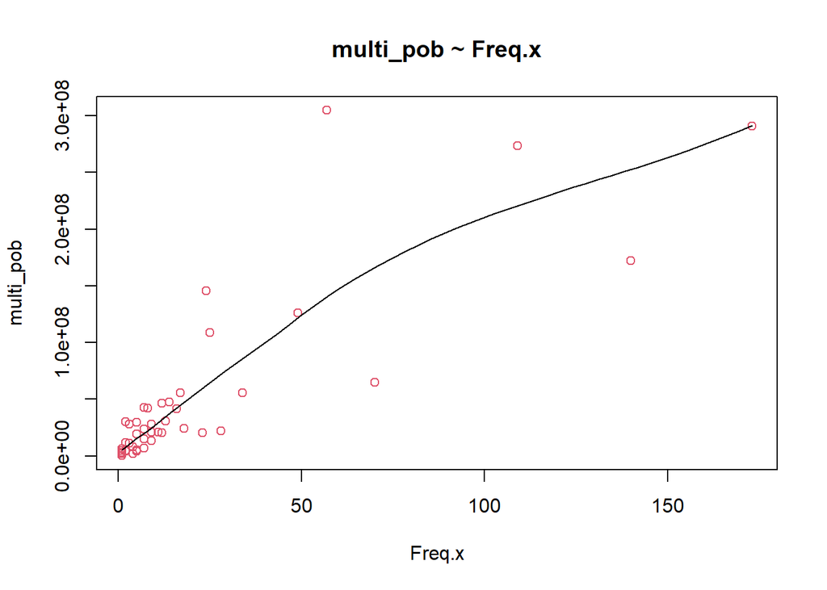

```r
scatter.smooth(x=h_y_m_comuna_corr_01$Freq.x, y=h_y_m_comuna_corr_01$multi_pob, main="multi_pob ~ Freq.x",
     xlab = "Freq.x",
     ylab = "multi_pob",
           col = 2)
```

### 7.2 Outliers

Hemos demostrado en el punto 5.7.2 de [aquí](https://rpubs.com/dataintelligence/expansion_viviendas_001) que la exclusión de ouliers no genera ninguna mejora en el modelo de regresión.

### 7.3 Modelo lineal

Aplicaremos un análisis de regresión lineal del ingreso expandido por zona sobre las frecuencias de respuestas zonales.

```r
linearMod <- lm( multi_pob~(Freq.x) , data=h_y_m_comuna_corr_01)
summary(linearMod)
```

```
##
## Call:
## lm(formula = multi_pob ~ (Freq.x), data = h_y_m_comuna_corr_01)
##
## Residuals:
##       Min        1Q    Median        3Q       Max
## -84163252 -13978538  -9182662   9257285 192968016
##
## Coefficients:
##             Estimate Std. Error t value Pr(>|t|)
## (Intercept) 12260378    6692183   1.832   0.0734 .
## Freq.x       1744893     166058  10.508 8.23e-14 ***
## ---
## Signif. codes:  0 '***' 0.001 '**' 0.01 '*' 0.05 '.' 0.1 ' ' 1
##
## Residual standard error: 40240000 on 46 degrees of freedom
## Multiple R-squared:  0.7059, Adjusted R-squared:  0.6995
## F-statistic: 110.4 on 1 and 46 DF,  p-value: 8.229e-14
```

### 7.4 Gráfica de la recta de regresión lineal

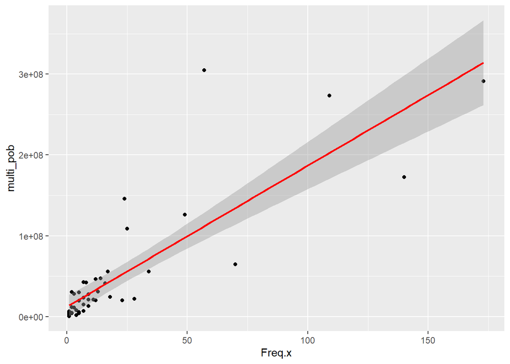

```r
ggplot(h_y_m_comuna_corr_01, aes(x = Freq.x , y = multi_pob)) +
  geom_point() +
  stat_smooth(method = "lm", col = "red")
```

## 8 Modelos alternativos

### 8.1 Modelo cuadrático

$$\hat Y = \beta_0 + \beta_1 X^2$$

```r
linearMod <- lm( multi_pob~(Freq.x^2) , data=h_y_m_comuna_corr_01)
summary(linearMod)
```

```
##
## Call:
## lm(formula = multi_pob ~ (Freq.x^2), data = h_y_m_comuna_corr_01)
##
## Residuals:
##       Min        1Q    Median        3Q       Max
## -84163252 -13978538  -9182662   9257285 192968016
##
## Coefficients:
##             Estimate Std. Error t value Pr(>|t|)
## (Intercept) 12260378    6692183   1.832   0.0734 .
## Freq.x       1744893     166058  10.508 8.23e-14 ***
## ---
## Signif. codes:  0 '***' 0.001 '**' 0.01 '*' 0.05 '.' 0.1 ' ' 1
##
## Residual standard error: 40240000 on 46 degrees of freedom
## Multiple R-squared:  0.7059, Adjusted R-squared:  0.6995
## F-statistic: 110.4 on 1 and 46 DF,  p-value: 8.229e-14
```

### 8.2 Modelo cúbico

$$\hat Y = \beta_0 + \beta_1 X^3$$

```r
linearMod <- lm( multi_pob~(Freq.x^3) , data=h_y_m_comuna_corr_01)
summary(linearMod)
```

```
##
## Call:
## lm(formula = multi_pob ~ (Freq.x^3), data = h_y_m_comuna_corr_01)
##
## Residuals:
##       Min        1Q    Median        3Q       Max
## -84163252 -13978538  -9182662   9257285 192968016
##
## Coefficients:
##             Estimate Std. Error t value Pr(>|t|)
## (Intercept) 12260378    6692183   1.832   0.0734 .
## Freq.x       1744893     166058  10.508 8.23e-14 ***
## ---
## Signif. codes:  0 '***' 0.001 '**' 0.01 '*' 0.05 '.' 0.1 ' ' 1
##
## Residual standard error: 40240000 on 46 degrees of freedom
## Multiple R-squared:  0.7059, Adjusted R-squared:  0.6995
## F-statistic: 110.4 on 1 and 46 DF,  p-value: 8.229e-14
```

### 8.3 Modelo logarítmico

$$\hat Y = \beta_0 + \beta_1 ln X$$

```r
linearMod <- lm( multi_pob~log(Freq.x) , data=h_y_m_comuna_corr_01)
summary(linearMod)
```

```
##
## Call:
## lm(formula = multi_pob ~ log(Freq.x), data = h_y_m_comuna_corr_01)
##
## Residuals:
##       Min        1Q    Median        3Q       Max
## -77032768 -30558701  -4968684  20340037 178049352
##
## Coefficients:
##              Estimate Std. Error t value Pr(>|t|)
## (Intercept) -31299018   12637927  -2.477    0.017 *
## log(Freq.x)  39063798    5181723   7.539 1.43e-09 ***
## ---
## Signif. codes:  0 '***' 0.001 '**' 0.01 '*' 0.05 '.' 0.1 ' ' 1
##
## Residual standard error: 49630000 on 46 degrees of freedom
## Multiple R-squared:  0.5527, Adjusted R-squared:  0.5429
## F-statistic: 56.83 on 1 and 46 DF,  p-value: 1.427e-09
```

### 8.4 Modelo exponencial

$$\hat Y = \beta_0 + \beta_1 e^X$$

No es aplicable sin una transformación pues los valores elevados a $e$ de Freq.x tienden a infinito.

### 8.5 Modelo con raíz cuadrada

$$\hat Y = \beta_0 + \beta_1 \sqrt {X}$$

```r
linearMod <- lm( multi_pob~sqrt(Freq.x) , data=h_y_m_comuna_corr_01)
summary(linearMod)
```

```
##
## Call:
## lm(formula = multi_pob ~ sqrt(Freq.x), data = h_y_m_comuna_corr_01)
##
## Residuals:
##       Min        1Q    Median        3Q       Max
## -90885719 -15339064    878178  12429953 167292894
##
## Coefficients:
##               Estimate Std. Error t value Pr(>|t|)
## (Intercept)  -31124865    9001459  -3.458  0.00118 **
## sqrt(Freq.x)  22320919    2011740  11.095 1.35e-14 ***
## ---
## Signif. codes:  0 '***' 0.001 '**' 0.01 '*' 0.05 '.' 0.1 ' ' 1
##
## Residual standard error: 38700000 on 46 degrees of freedom
## Multiple R-squared:  0.728,  Adjusted R-squared:  0.7221
## F-statistic: 123.1 on 1 and 46 DF,  p-value: 1.348e-14
```

### 8.6 Modelo raíz-raíz

$$\hat Y = {\beta_0}^2 + 2 \beta_0 \beta_1 \sqrt{X}+ \beta_1^2 X$$

```r
linearMod <- lm( sqrt(multi_pob)~sqrt(Freq.x) , data=h_y_m_comuna_corr_01)
summary(linearMod)
```

```
##
## Call:
## lm(formula = sqrt(multi_pob) ~ sqrt(Freq.x), data = h_y_m_comuna_corr_01)
##
## Residuals:
##     Min      1Q  Median      3Q     Max
## -3742.7  -999.9  -185.9  1056.5  6716.3
##
## Coefficients:
##              Estimate Std. Error t value Pr(>|t|)
## (Intercept)    1034.6      457.9    2.26   0.0286 *
## sqrt(Freq.x)   1285.4      102.3   12.56   <2e-16 ***
## ---
## Signif. codes:  0 '***' 0.001 '**' 0.01 '*' 0.05 '.' 0.1 ' ' 1
##
## Residual standard error: 1969 on 46 degrees of freedom
## Multiple R-squared:  0.7743, Adjusted R-squared:  0.7694
## F-statistic: 157.8 on 1 and 46 DF,  p-value: < 2.2e-16
```

### 8.7 Modelo log-raíz

$$\hat Y = e^{\beta_0 + \beta_1 \sqrt{X}}$$

```r
linearMod <- lm( log(multi_pob)~sqrt(Freq.x) , data=h_y_m_comuna_corr_01)
summary(linearMod)
```

```
##
## Call:
## lm(formula = log(multi_pob) ~ sqrt(Freq.x), data = h_y_m_comuna_corr_01)
##
## Residuals:
##     Min      1Q  Median      3Q     Max
## -3.2898 -0.5916  0.1082  0.5877  1.4843
##
## Coefficients:
##              Estimate Std. Error t value Pr(>|t|)
## (Intercept)  15.34452    0.21350  71.871  < 2e-16 ***
## sqrt(Freq.x)  0.40171    0.04772   8.419 7.19e-11 ***
## ---
## Signif. codes:  0 '***' 0.001 '**' 0.01 '*' 0.05 '.' 0.1 ' ' 1
##
## Residual standard error: 0.9179 on 46 degrees of freedom
## Multiple R-squared:  0.6064, Adjusted R-squared:  0.5979
## F-statistic: 70.88 on 1 and 46 DF,  p-value: 7.188e-11
```

### 8.8 Modelo raíz-log

$$\hat Y = {\beta_0}^2 + 2 \beta_0 \beta_1 \ln{X}+ \beta_1^2 ln^2X$$

```r
linearMod <- lm( sqrt(multi_pob)~log(Freq.x) , data=h_y_m_comuna_corr_01)
summary(linearMod)
```

```
##
## Call:
## lm(formula = sqrt(multi_pob) ~ log(Freq.x), data = h_y_m_comuna_corr_01)
##
## Residuals:
##     Min      1Q  Median      3Q     Max
## -4131.7 -1572.9  -100.1  1167.7  6898.9
##
## Coefficients:
##             Estimate Std. Error t value Pr(>|t|)
## (Intercept)    592.9      572.7   1.035    0.306
## log(Freq.x)   2464.4      234.8  10.496 8.54e-14 ***
## ---
## Signif. codes:  0 '***' 0.001 '**' 0.01 '*' 0.05 '.' 0.1 ' ' 1
##
## Residual standard error: 2249 on 46 degrees of freedom
## Multiple R-squared:  0.7054, Adjusted R-squared:  0.699
## F-statistic: 110.2 on 1 and 46 DF,  p-value: 8.543e-14
```

### 8.9 Modelo log-log

$$\hat Y = e^{\beta_0+\beta_1 ln{X}}$$

```r
linearMod <- lm( log(multi_pob)~log(Freq.x) , data=h_y_m_comuna_corr_01)
summary(linearMod)
```

```
##
## Call:
## lm(formula = log(multi_pob) ~ log(Freq.x), data = h_y_m_comuna_corr_01)
##
## Residuals:
##      Min       1Q   Median       3Q      Max
## -2.53182 -0.36630  0.07116  0.44044  1.62651
##
## Coefficients:
##             Estimate Std. Error t value Pr(>|t|)
## (Intercept) 14.98827    0.19740   75.93  < 2e-16 ***
## log(Freq.x)  0.87877    0.08094   10.86 2.79e-14 ***
## ---
## Signif. codes:  0 '***' 0.001 '**' 0.01 '*' 0.05 '.' 0.1 ' ' 1
##
## Residual standard error: 0.7751 on 46 degrees of freedom
## Multiple R-squared:  0.7193, Adjusted R-squared:  0.7132
## F-statistic: 117.9 on 1 and 46 DF,  p-value: 2.787e-14
```

## 9 Modelo elegido: raíz-raíz (**sqrt-sqrt**)

Es éste el modelo que nos entrega el mayor coeficiente de determinación de todos (0.7694).

### 9.1 Diagrama de dispersión sobre **sqrt-sqrt**

Desplegamos una curva suavizada por loess en el diagrama de dispersión.

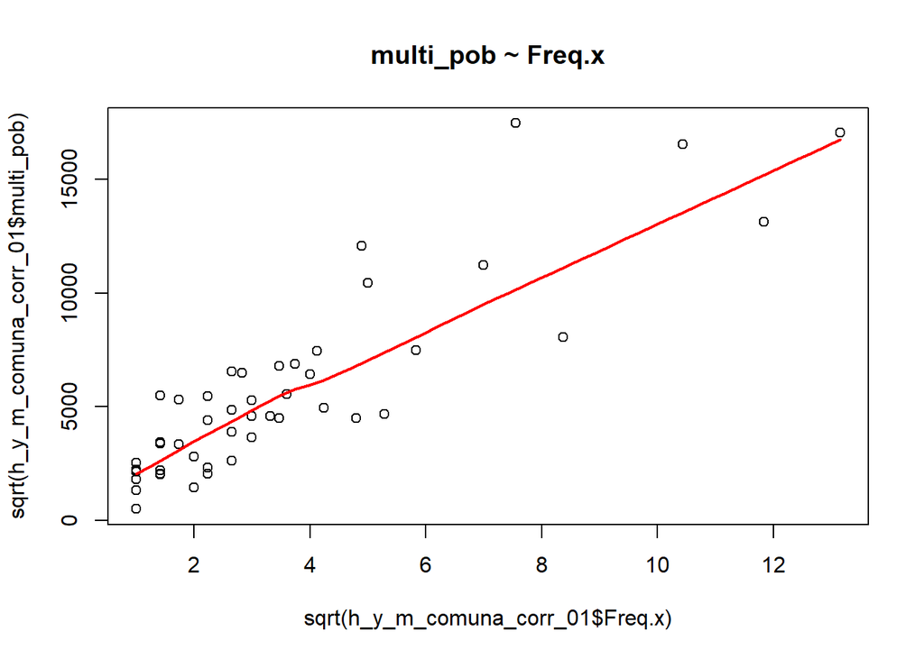

```r
scatter.smooth(x=sqrt(h_y_m_comuna_corr_01$Freq.x), y=sqrt(h_y_m_comuna_corr_01$multi_pob), lpars = list(col = "red", lwd = 2, lty = 1), main="multi_pob ~ Freq.x")
```

### 9.2 Modelo **sqrt-sqrt**

Observemos nuevamente el resultado sobre **sqrt-sqrt**.

```r
linearMod <- lm(sqrt( multi_pob)~sqrt(Freq.x) , data=h_y_m_comuna_corr_01)
summary(linearMod)
```

```
##
## Call:
## lm(formula = sqrt(multi_pob) ~ sqrt(Freq.x), data = h_y_m_comuna_corr_01)
##
## Residuals:
##     Min      1Q  Median      3Q     Max
## -3742.7  -999.9  -185.9  1056.5  6716.3
##
## Coefficients:
##              Estimate Std. Error t value Pr(>|t|)
## (Intercept)    1034.6      457.9    2.26   0.0286 *
## sqrt(Freq.x)   1285.4      102.3   12.56   <2e-16 ***
## ---
## Signif. codes:  0 '***' 0.001 '**' 0.01 '*' 0.05 '.' 0.1 ' ' 1
##
## Residual standard error: 1969 on 46 degrees of freedom
## Multiple R-squared:  0.7743, Adjusted R-squared:  0.7694
## F-statistic: 157.8 on 1 and 46 DF,  p-value: < 2.2e-16
```

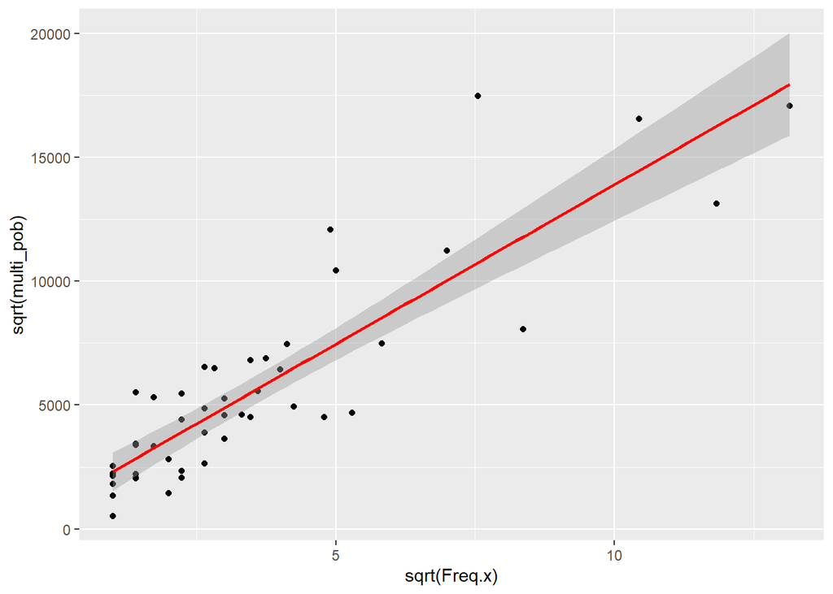

```r
ggplot(h_y_m_comuna_corr_01, aes(x = sqrt(Freq.x) , y = sqrt(multi_pob))) +
  geom_point() +
  stat_smooth(method = "lm", col = "red")
```

### 9.3 Análisis de residuos

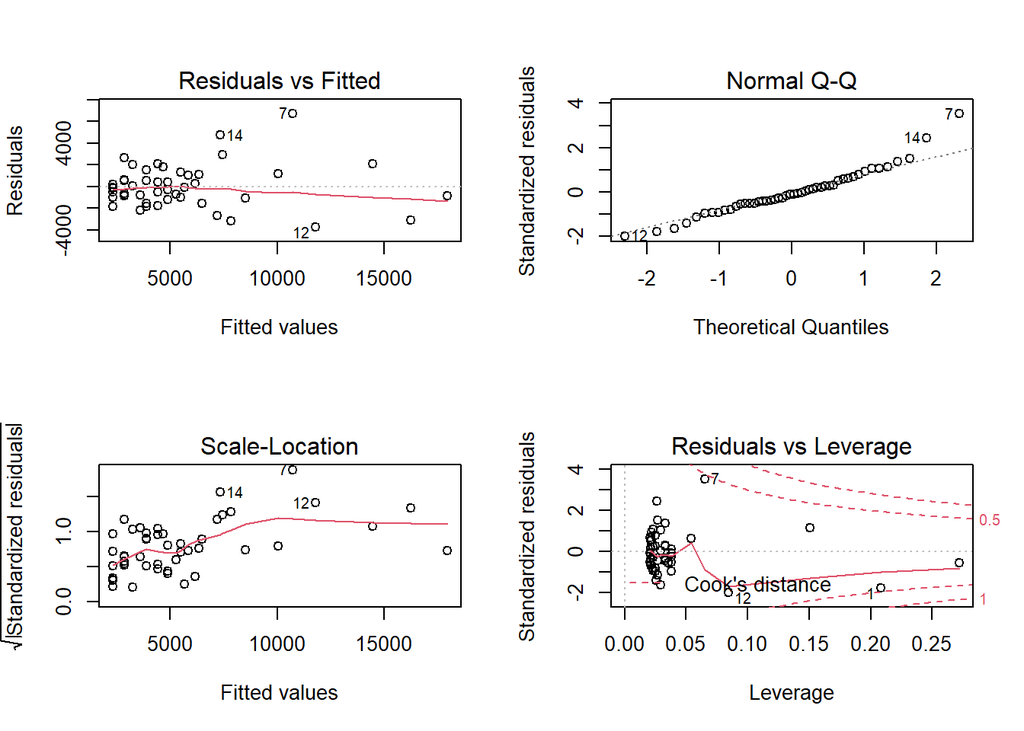

```r
par(mfrow = c (2,2))
plot(linearMod)
```

### 9.4 Ecuación del modelo

$$\hat Y = {1034.6}^2 + 2 \cdot 1034.6 \cdot 1285.4 \sqrt{X}+ 1285.4^2 \cdot X$$

## 10 Aplicación la regresión a los valores de la variable a nivel de zona

Esta nueva variable se llamará: est_ing

```r
h_y_m_comuna_corr_01$est_ing <-
(1034.6)^2 + 2 * 1034.6 * 1285.4 * sqrt(h_y_m_comuna_corr_01$Freq.x)+  1285.4^2 * (h_y_m_comuna_corr_01$Freq.x)

r3_100 <- h_y_m_comuna_corr_01[c(1:100),]
kbl(r3_100) %>%
  kable_styling(bootstrap_options = c("striped", "hover")) %>%
  kable_paper() %>%
  scroll_box(width = "100%", height = "300px")
```

|  | zona | código.x | Freq.x | anio | comuna.x | promedio_i | año | personas | Ingresos_expandidos | Freq.y | p_poblacional | código.y | multi_pob | est_ing |
| --- | --- | --- | --- | --- | --- | --- | --- | --- | --- | --- | --- | --- | --- | --- |
| 1 | 12101092005 | 12101 | 140 | 2017 | Punta Arenas | 256903.3 | 2017 | 131592 | 33806414442 | 671 | 0.0050991 | 12101 | 172382090.8 | 263856422 |
| 2 | 12101092006 | 12101 | 23 | 2017 | Punta Arenas | 256903.3 | 2017 | 131592 | 33806414442 | 79 | 0.0006003 | 12101 | 20295357.9 | 51827931 |
| 3 | 12101092007 | 12101 | 2 | 2017 | Punta Arenas | 256903.3 | 2017 | 131592 | 33806414442 | 16 | 0.0001216 | 12101 | 4110452.2 | 8136358 |
| 4 | 12101092009 | 12101 | 18 | 2017 | Punta Arenas | 256903.3 | 2017 | 131592 | 33806414442 | 95 | 0.0007219 | 12101 | 24405810.2 | 42095316 |
| 5 | 12101092014 | 12101 | 1 | 2017 | Punta Arenas | 256903.3 | 2017 | 131592 | 33806414442 | 7 | 0.0000532 | 12101 | 1798322.9 | 5382400 |
| 6 | 12101092016 | 12101 | 12 | 2017 | Punta Arenas | 256903.3 | 2017 | 131592 | 33806414442 | 79 | 0.0006003 | 12101 | 20295357.9 | 30111078 |
| 7 | 12101092019 | 12101 | 57 | 2017 | Punta Arenas | 256903.3 | 2017 | 131592 | 33806414442 | 1186 | 0.0090127 | 12101 | 304687272.2 | 115329497 |
| 8 | 12101092020 | 12101 | 49 | 2017 | Punta Arenas | 256903.3 | 2017 | 131592 | 33806414442 | 491 | 0.0037312 | 12101 | 126139503.1 | 100649050 |
| 9 | 12101092032 | 12101 | 109 | 2017 | Punta Arenas | 256903.3 | 2017 | 131592 | 33806414442 | 1064 | 0.0080856 | 12101 | 273345073.9 | 208934593 |
| 10 | 12101092901 | 12101 | 2 | 2017 | Punta Arenas | 256903.3 | 2017 | 131592 | 33806414442 | 19 | 0.0001444 | 12101 | 4881162.0 | 8136358 |
| 11 | 12101102002 | 12101 | 12 | 2017 | Punta Arenas | 256903.3 | 2017 | 131592 | 33806414442 | 180 | 0.0013679 | 12101 | 46242587.7 | 30111078 |
| 12 | 12101102015 | 12101 | 70 | 2017 | Punta Arenas | 256903.3 | 2017 | 131592 | 33806414442 | 252 | 0.0019150 | 12101 | 64739622.8 | 138981181 |
| 13 | 12101102017 | 12101 | 9 | 2017 | Punta Arenas | 256903.3 | 2017 | 131592 | 33806414442 | 108 | 0.0008207 | 12101 | 27745552.6 | 23919925 |
| 14 | 12101102021 | 12101 | 24 | 2017 | Punta Arenas | 256903.3 | 2017 | 131592 | 33806414442 | 567 | 0.0043088 | 12101 | 145664151.2 | 53754532 |
| 15 | 12101102029 | 12101 | 5 | 2017 | Punta Arenas | 256903.3 | 2017 | 131592 | 33806414442 | 76 | 0.0005775 | 12101 | 19524648.1 | 15279044 |
| 16 | 12101102030 | 12101 | 28 | 2017 | Punta Arenas | 256903.3 | 2017 | 131592 | 33806414442 | 85 | 0.0006459 | 12101 | 21836777.5 | 61407558 |
| 17 | 12101102033 | 12101 | 5 | 2017 | Punta Arenas | 256903.3 | 2017 | 131592 | 33806414442 | 116 | 0.0008815 | 12101 | 29800778.7 | 15279044 |
| 18 | 12101102901 | 12101 | 7 | 2017 | Punta Arenas | 256903.3 | 2017 | 131592 | 33806414442 | 59 | 0.0004484 | 12101 | 15157292.6 | 19673205 |
| 19 | 12101112901 | 12101 | 1 | 2017 | Punta Arenas | 256903.3 | 2017 | 131592 | 33806414442 | 25 | 0.0001900 | 12101 | 6422581.6 | 5382400 |
| 20 | 12101122001 | 12101 | 14 | 2017 | Punta Arenas | 256903.3 | 2017 | 131592 | 33806414442 | 184 | 0.0013983 | 12101 | 47270200.8 | 34153813 |
| 21 | 12101122010 | 12101 | 4 | 2017 | Punta Arenas | 256903.3 | 2017 | 131592 | 33806414442 | 8 | 0.0000608 | 12101 | 2055226.1 | 12998909 |
| 22 | 12101122026 | 12101 | 1 | 2017 | Punta Arenas | 256903.3 | 2017 | 131592 | 33806414442 | 1 | 0.0000076 | 12101 | 256903.3 | 5382400 |
| 23 | 12101142011 | 12101 | 17 | 2017 | Punta Arenas | 256903.3 | 2017 | 131592 | 33806414442 | 217 | 0.0016490 | 12101 | 55748008.5 | 40125130 |
| 24 | 12301012007 | 12301 | 7 | 2017 | Porvenir | 381329.2 | 2017 | 6801 | 2593419712 | 112 | 0.0164682 | 12301 | 42708867.5 | 19673205 |
| 25 | 12301012008 | 12301 | 3 | 2017 | Porvenir | 381329.2 | 2017 | 6801 | 2593419712 | 74 | 0.0108808 | 12301 | 28218358.9 | 10633978 |
| 26 | 12301022006 | 12301 | 1 | 2017 | Porvenir | 381329.2 | 2017 | 6801 | 2593419712 | 12 | 0.0017644 | 12301 | 4575950.1 | 5382400 |
| 27 | 12301022010 | 12301 | 1 | 2017 | Porvenir | 381329.2 | 2017 | 6801 | 2593419712 | 13 | 0.0019115 | 12301 | 4957279.3 | 5382400 |
| 28 | 12301032002 | 12301 | 9 | 2017 | Porvenir | 381329.2 | 2017 | 6801 | 2593419712 | 55 | 0.0080870 | 12301 | 20973104.6 | 23919925 |
| 29 | 12301032003 | 12301 | 7 | 2017 | Porvenir | 381329.2 | 2017 | 6801 | 2593419712 | 62 | 0.0091163 | 12301 | 23642408.8 | 19673205 |
| 30 | 12301032011 | 12301 | 25 | 2017 | Porvenir | 381329.2 | 2017 | 6801 | 2593419712 | 285 | 0.0419056 | 12301 | 108678814.6 | 55675475 |

[output cut: 70 more lines]

## 11 División del valor estimado entre la población total de la zona para obtener el ingreso medio por zona

$$Ingreso \_ Medio\_zona = est\_ing / (personas * p\_poblacional)$$

```r
h_y_m_comuna_corr_01$ing_medio_zona <- h_y_m_comuna_corr_01$est_ing  /( h_y_m_comuna_corr_01$personas  * h_y_m_comuna_corr_01$p_poblacional)

r3_100 <- h_y_m_comuna_corr_01[c(1:100),]
kbl(r3_100) %>%
  kable_styling(bootstrap_options = c("striped", "hover")) %>%
  kable_paper() %>%
  scroll_box(width = "100%", height = "300px")
```

|  | zona | código.x | Freq.x | anio | comuna.x | promedio_i | año | personas | Ingresos_expandidos | Freq.y | p_poblacional | código.y | multi_pob | est_ing | ing_medio_zona |
| --- | --- | --- | --- | --- | --- | --- | --- | --- | --- | --- | --- | --- | --- | --- | --- |
| 1 | 12101092005 | 12101 | 140 | 2017 | Punta Arenas | 256903.3 | 2017 | 131592 | 33806414442 | 671 | 0.0050991 | 12101 | 172382090.8 | 263856422 | 393228.65 |
| 2 | 12101092006 | 12101 | 23 | 2017 | Punta Arenas | 256903.3 | 2017 | 131592 | 33806414442 | 79 | 0.0006003 | 12101 | 20295357.9 | 51827931 | 656049.76 |
| 3 | 12101092007 | 12101 | 2 | 2017 | Punta Arenas | 256903.3 | 2017 | 131592 | 33806414442 | 16 | 0.0001216 | 12101 | 4110452.2 | 8136358 | 508522.35 |
| 4 | 12101092009 | 12101 | 18 | 2017 | Punta Arenas | 256903.3 | 2017 | 131592 | 33806414442 | 95 | 0.0007219 | 12101 | 24405810.2 | 42095316 | 443108.59 |
| 5 | 12101092014 | 12101 | 1 | 2017 | Punta Arenas | 256903.3 | 2017 | 131592 | 33806414442 | 7 | 0.0000532 | 12101 | 1798322.9 | 5382400 | 768914.29 |
| 6 | 12101092016 | 12101 | 12 | 2017 | Punta Arenas | 256903.3 | 2017 | 131592 | 33806414442 | 79 | 0.0006003 | 12101 | 20295357.9 | 30111078 | 381152.89 |
| 7 | 12101092019 | 12101 | 57 | 2017 | Punta Arenas | 256903.3 | 2017 | 131592 | 33806414442 | 1186 | 0.0090127 | 12101 | 304687272.2 | 115329497 | 97242.41 |
| 8 | 12101092020 | 12101 | 49 | 2017 | Punta Arenas | 256903.3 | 2017 | 131592 | 33806414442 | 491 | 0.0037312 | 12101 | 126139503.1 | 100649050 | 204987.88 |
| 9 | 12101092032 | 12101 | 109 | 2017 | Punta Arenas | 256903.3 | 2017 | 131592 | 33806414442 | 1064 | 0.0080856 | 12101 | 273345073.9 | 208934593 | 196367.10 |
| 10 | 12101092901 | 12101 | 2 | 2017 | Punta Arenas | 256903.3 | 2017 | 131592 | 33806414442 | 19 | 0.0001444 | 12101 | 4881162.0 | 8136358 | 428229.34 |
| 11 | 12101102002 | 12101 | 12 | 2017 | Punta Arenas | 256903.3 | 2017 | 131592 | 33806414442 | 180 | 0.0013679 | 12101 | 46242587.7 | 30111078 | 167283.77 |
| 12 | 12101102015 | 12101 | 70 | 2017 | Punta Arenas | 256903.3 | 2017 | 131592 | 33806414442 | 252 | 0.0019150 | 12101 | 64739622.8 | 138981181 | 551512.62 |
| 13 | 12101102017 | 12101 | 9 | 2017 | Punta Arenas | 256903.3 | 2017 | 131592 | 33806414442 | 108 | 0.0008207 | 12101 | 27745552.6 | 23919925 | 221480.78 |
| 14 | 12101102021 | 12101 | 24 | 2017 | Punta Arenas | 256903.3 | 2017 | 131592 | 33806414442 | 567 | 0.0043088 | 12101 | 145664151.2 | 53754532 | 94805.17 |
| 15 | 12101102029 | 12101 | 5 | 2017 | Punta Arenas | 256903.3 | 2017 | 131592 | 33806414442 | 76 | 0.0005775 | 12101 | 19524648.1 | 15279044 | 201040.05 |
| 16 | 12101102030 | 12101 | 28 | 2017 | Punta Arenas | 256903.3 | 2017 | 131592 | 33806414442 | 85 | 0.0006459 | 12101 | 21836777.5 | 61407558 | 722441.86 |
| 17 | 12101102033 | 12101 | 5 | 2017 | Punta Arenas | 256903.3 | 2017 | 131592 | 33806414442 | 116 | 0.0008815 | 12101 | 29800778.7 | 15279044 | 131715.90 |
| 18 | 12101102901 | 12101 | 7 | 2017 | Punta Arenas | 256903.3 | 2017 | 131592 | 33806414442 | 59 | 0.0004484 | 12101 | 15157292.6 | 19673205 | 333444.16 |
| 19 | 12101112901 | 12101 | 1 | 2017 | Punta Arenas | 256903.3 | 2017 | 131592 | 33806414442 | 25 | 0.0001900 | 12101 | 6422581.6 | 5382400 | 215296.00 |
| 20 | 12101122001 | 12101 | 14 | 2017 | Punta Arenas | 256903.3 | 2017 | 131592 | 33806414442 | 184 | 0.0013983 | 12101 | 47270200.8 | 34153813 | 185618.55 |
| 21 | 12101122010 | 12101 | 4 | 2017 | Punta Arenas | 256903.3 | 2017 | 131592 | 33806414442 | 8 | 0.0000608 | 12101 | 2055226.1 | 12998909 | 1624863.65 |
| 22 | 12101122026 | 12101 | 1 | 2017 | Punta Arenas | 256903.3 | 2017 | 131592 | 33806414442 | 1 | 0.0000076 | 12101 | 256903.3 | 5382400 | 5382400.00 |
| 23 | 12101142011 | 12101 | 17 | 2017 | Punta Arenas | 256903.3 | 2017 | 131592 | 33806414442 | 217 | 0.0016490 | 12101 | 55748008.5 | 40125130 | 184908.43 |
| 24 | 12301012007 | 12301 | 7 | 2017 | Porvenir | 381329.2 | 2017 | 6801 | 2593419712 | 112 | 0.0164682 | 12301 | 42708867.5 | 19673205 | 175653.62 |
| 25 | 12301012008 | 12301 | 3 | 2017 | Porvenir | 381329.2 | 2017 | 6801 | 2593419712 | 74 | 0.0108808 | 12301 | 28218358.9 | 10633978 | 143702.41 |
| 26 | 12301022006 | 12301 | 1 | 2017 | Porvenir | 381329.2 | 2017 | 6801 | 2593419712 | 12 | 0.0017644 | 12301 | 4575950.1 | 5382400 | 448533.33 |
| 27 | 12301022010 | 12301 | 1 | 2017 | Porvenir | 381329.2 | 2017 | 6801 | 2593419712 | 13 | 0.0019115 | 12301 | 4957279.3 | 5382400 | 414030.77 |
| 28 | 12301032002 | 12301 | 9 | 2017 | Porvenir | 381329.2 | 2017 | 6801 | 2593419712 | 55 | 0.0080870 | 12301 | 20973104.6 | 23919925 | 434907.72 |
| 29 | 12301032003 | 12301 | 7 | 2017 | Porvenir | 381329.2 | 2017 | 6801 | 2593419712 | 62 | 0.0091163 | 12301 | 23642408.8 | 19673205 | 317309.77 |
| 30 | 12301032011 | 12301 | 25 | 2017 | Porvenir | 381329.2 | 2017 | 6801 | 2593419712 | 285 | 0.0419056 | 12301 | 108678814.6 | 55675475 | 195352.54 |

[output cut: 70 more lines]

Guardamos:

```r
saveRDS(h_y_m_comuna_corr_01, "P15/region_12_P15_r.rds")
```

## 12 Referencias

https://rpubs.com/osoramirez/316691

https://dataintelligencechile.shinyapps.io/casenfinal

Manual_de_usuario_Censo_2017_16R.pdf

http://www.censo2017.cl/microdatos/

Censo de Población y Vivienda

https://www.ine.cl/estadisticas/sociales/censos-de-poblacion-y-vivienda/poblacion-y-vivienda

http://r-statistics.co/Linear-Regression.html